# Migration Rates By Age

American Community Survey 2023

Author

Gavin Morrow

Published

Feb 4, 2026

## Set libraries and directories

```r
library(ipumsr)
library(tidyverse)
library(gt)
library(scales)

# wkdir is the root of your project directory
wkdir <- here::here()

# set directories for where you store data and save plots relative to project root
dataDir <- file.path(wkdir, "data")  #read data file dir
plotsDir <- file.path(wkdir, "plots")  #save plot files dir

options(scipen=99, digits=5)

# create plots drectory if it does not exist
ifelse(!dir.exists(file.path(wkdir, "plots")), dir.create(file.path(wkdir, "plots")), FALSE)

# dataset

options(scipen=99, digits=5)
```

# This analysis uses 2023 ACS data from IPUMS USA, University of Minnesota, www.ipums.org

```r
if (!require("ipumsr")) stop("Reading IPUMS data into R requires the ipumsr package. It can be installed using the following command: install.packages('ipumsr')")

dataSet <- "usa_00001.xml"

ddi <- read_ipums_ddi(file.path(dataDir,dataSet)) # ACS 2018
data <- read_ipums_micro(ddi)
```

```
Use of data from IPUMS USA is subject to conditions including that users should cite the data appropriately. Use command `ipums_conditions()` for more details.
```

```r
# Remove bad data from 2000
data <- data %>%
  filter(YEAR != 2000)
# extract variable names the traditional way (useful reference)
varname <- as.data.frame(colnames(data))

# create webpage of variable names, labels and values, save it as dataSet.html in the data directory
# useful for reference
ipums_view(ddi, launch = FALSE, out_file=file.path(wkdir, "data", paste0(dataSet,".html" )))
```

```
[1] "C:/Users/gavjm/OneDrive/Documents/GEOG456/data/usa_00001.xml.html"
```

```r
# add a state name variable to data (not used in this analysis but useful for later work)
# first, create a dataframe with statefips codes (as val) and statenames (as lbl) from variable STATEIP
STATES <- ipums_val_labels(ddi, STATEFIP)

# then, join STATES to data (using: STATEFIP=val) and rename new variable lbl as STATENAME
data <- data %>%
  left_join(select(STATES, STATEFIP=val, STATENAME=lbl))
```

## Compute Unweighted National Migration Rate

```r
migrate_national_unweighted <- data %>%
  filter(AGE>=1) %>%
  mutate(n=1) %>%
  summarise(pop=sum(n),
         interstate_movers=sum(n[MIGRATE1==3])) %>%
  mutate(interstate_mig_rate=interstate_movers/pop)

gt(head(migrate_national_unweighted)) %>%
  opt_table_font(size = 40) %>%
  cols_align(
    align = "center",
  )
```

| pop | interstate_movers | interstate_mig_rate |
| --- | --- | --- |
| 3376341 | 75207 | 0.022275 |

## Compute Weighted National Migration Rate

When applying weights from our data we account for representation of the total population and thus we get 2.3% instead of 2.2% as older people do not tend to migrate.

```r
migrate_national_weighted <- data %>%
  filter(AGE>=1) %>%
  summarise(pop=sum(PERWT),
         interstate_movers=sum(PERWT[MIGRATE1==3])) %>%
  mutate(interstate_mig_rate=interstate_movers/pop)

gt(head(migrate_national_weighted)) %>%
  opt_table_font(size = 40) %>%
  cols_align(
    align = "center",
  )
```

| pop | interstate_movers | interstate_mig_rate |
| --- | --- | --- |
| 331423217 | 7622620 | 0.023 |

## Compute Weighted National Migration Rates by Age

As we can see younger people move a lot more and by age groups that slowly tapers off.

```r
migrate_age <- data %>%
  filter(AGE>=1) %>%
  group_by(AGE) %>%
  summarise(pop=sum(PERWT),
         interstate_movers=sum(PERWT[MIGRATE1==3])) %>%
  mutate(interstate_mig_rate=interstate_movers/pop)

gt(head(migrate_age))
```

| Age | pop | interstate_movers | interstate_mig_rate |
| --- | --- | --- | --- |
| 1 | 3618383 | 106575 | 0.029454 |
| 2 | 3596000 | 100208 | 0.027867 |
| 3 | 3774804 | 85500 | 0.022650 |
| 4 | 3813505 | 82469 | 0.021626 |
| 5 | 3789525 | 79887 | 0.021081 |
| 6 | 3867880 | 71146 | 0.018394 |

## Plot migration rates by age: a migration schedule by age

A clear pattern shows young adults move more

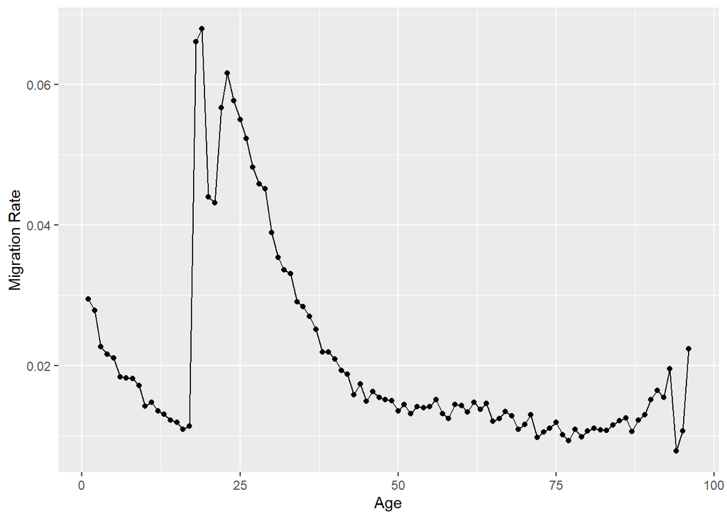

```r
ggplot(data=migrate_age, aes(x=AGE, y=interstate_mig_rate)) +
  geom_line()+
  geom_point() +
  scale_x_continuous(name="Age") +
  scale_y_continuous(name="Migration Rate")
```

## Add title, axis names and better label tick marks

Better labeling and tick marks

Save plot as png

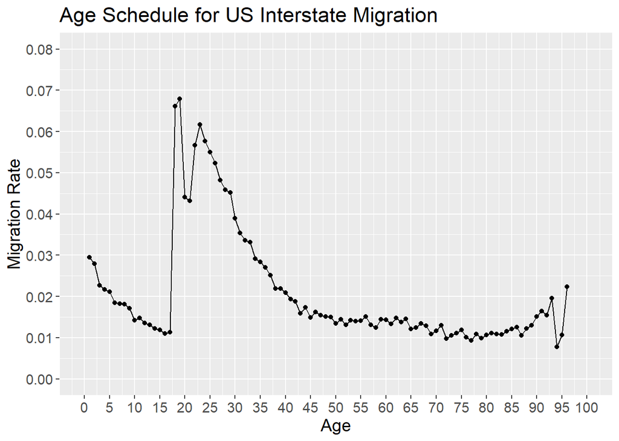

```r
ggplot(data=migrate_age, aes(x=AGE, y=interstate_mig_rate)) +
  geom_line()+
  geom_point() +
  scale_x_continuous(name="Age", limits=c(0,100), breaks=seq(0,100, by = 5)) +
  scale_y_continuous(name="Migration Rate", limits=c(0,0.08), breaks=seq(0,0.08, by =0.01)) +
  labs(title = "Age Schedule for US Interstate Migration") +
  theme(text=element_text(size=14))
```

```r
ggsave(path=plotsDir, filename='age_schedule_2018.png',dpi=600)
```

## Smooth the age schedule

Get rid of the jerky trend line and replace with a smoothed one. It does not capture the extremes but does show the general trends.

Save plot as png

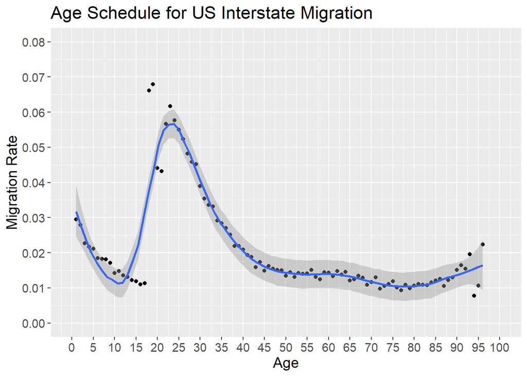

```r
ggplot(data=migrate_age, aes(x=AGE, y=interstate_mig_rate)) +
  geom_point() +
  geom_smooth(span=.24) +
  scale_x_continuous(name="Age", limits=c(0,100), breaks=seq(0,100, by = 5)) +
  scale_y_continuous(name="Migration Rate", limits=c(0,0.08), breaks=seq(0,0.08, by =0.01)) +
  labs(title = "Age Schedule for US Interstate Migration") +
  theme(text=element_text(size=14))
```

```r
ggsave(path=plotsDir, filename='age_schedule_smoothed_2018.png',dpi=600)
```

## Plot rates as percentages

Save plot

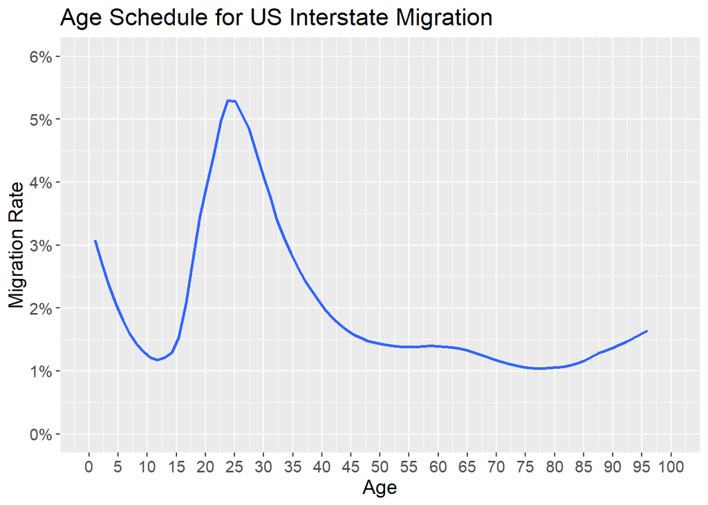

```r
ggplot(data=migrate_age, aes(x=AGE, y=interstate_mig_rate)) +
  geom_smooth(span=.24, se=FALSE) +
  scale_x_continuous(name="Age", limits=c(0,100), breaks=seq(0,100, by = 5)) +
  scale_y_continuous(name="Migration Rate", limits=c(0,0.06), breaks=seq(0,0.6, by =0.01),
                     labels=percent) +
  labs(title = "Age Schedule for US Interstate Migration") +
  theme(text=element_text(size=14))
```

```r
ggsave(path=plotsDir, filename='age_schedule_2018_percent_smoothed.png',dpi=600)
```

## Create five year pooled migration rates by age

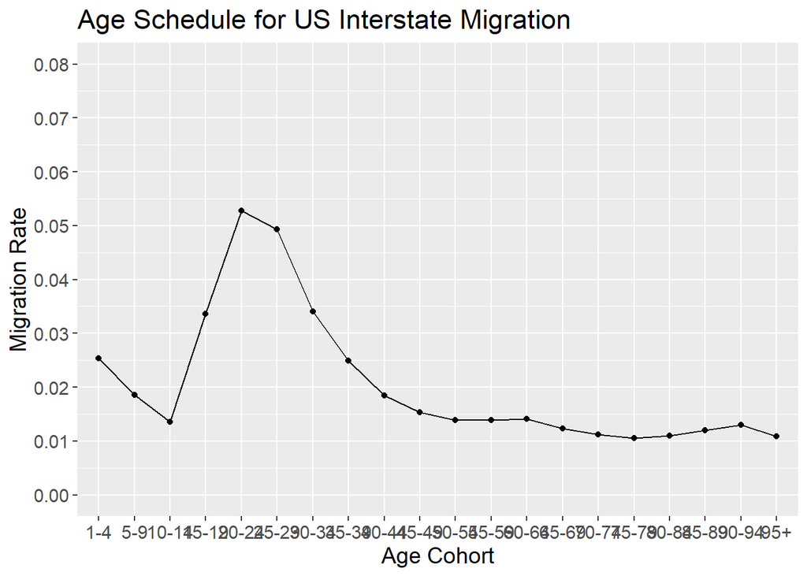

```r
migrate_age_5 <- data %>%
  filter(AGE>=1) %>%
  mutate(agegroup=cut(AGE, breaks=c(0,5,10,15,20,25,30,35,40,45,50,55,60,65,70,75,80,85,90,95,500), right=F,
                      labels=c("1-4","5-9","10-14","15-19","20-24","25-29","30-34","35-39","40-44","45-49",
                               "50-54","55-59","60-64","65-69","70-74","75-79","80-84",
                               "85-89","90-94","95+"))) %>%
  group_by(agegroup) %>%
  summarise(pop=sum(PERWT),
         interstate_movers=sum(PERWT[MIGRATE1==3])) %>%
  mutate(interstate_mig_rate=interstate_movers/pop) %>%
  ungroup()


ggplot(data=migrate_age_5, aes(x=agegroup, y=interstate_mig_rate, group=1)) +
  geom_line()+
  geom_point() +
  scale_y_continuous(name="Migration Rate", limits=c(0,0.08), breaks=seq(0,0.08, by =0.01))+
  scale_x_discrete(name="Age Cohort") +
  labs(title = "Age Schedule for US Interstate Migration") +
  theme(text=element_text(size=14))
```

## Reduce x-axis tick font size to be more readable

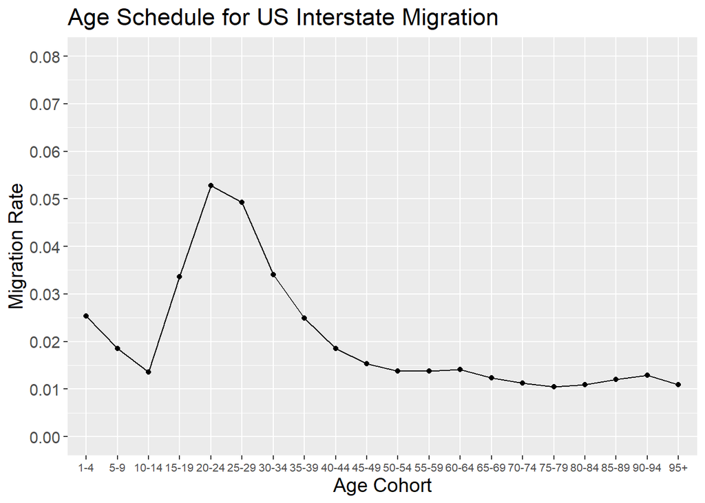

```r
ggplot(data=migrate_age_5, aes(x=agegroup, y=interstate_mig_rate, group=1)) +
  geom_line()+
  geom_point() +
  scale_y_continuous(name="Migration Rate", limits=c(0,0.08), breaks=seq(0,0.08, by =0.01))+
  scale_x_discrete(name="Age Cohort") +
  labs(title = "Age Schedule for US Interstate Migration") +
  theme(text=element_text(size=14),
        axis.text.x = element_text(size=8))
```

## Rotate x-axis tick labels to be more readable

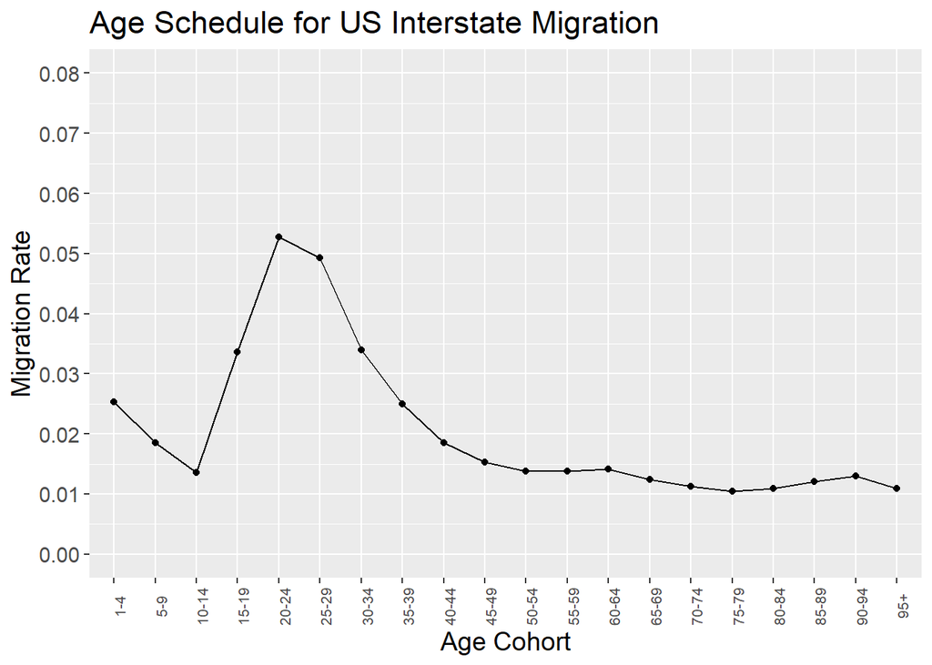

```r
ggplot(data=migrate_age_5, aes(x=agegroup, y=interstate_mig_rate, group=1)) +
  geom_line()+
  geom_point() +
  scale_y_continuous(name="Migration Rate", limits=c(0,0.08), breaks=seq(0,0.08, by =0.01))+
  scale_x_discrete(name="Age Cohort") +
  labs(title = "Age Schedule for US Interstate Migration") +
  theme(text=element_text(size=14),
        axis.text.x = element_text(size=8, angle=90))
```

## Migration Rates by Race

```r
migrate_race <- data %>%
  filter(AGE>=1) %>%
  mutate(RACE_ETHNIC=case_when(
    HISPAN==0 & RACE==1 ~ "White",
    HISPAN==0 & RACE==2 ~ "Black",
    HISPAN==0 & RACE==3 ~ "American Indian",
    HISPAN==0 & (RACE>=4 & RACE <=6) ~ "Asian",
    HISPAN==0 & RACE==7 ~ "Other",
    HISPAN==0 & RACE>=8 ~ "Mixed",
    HISPAN>0 ~ "Latino")) %>%
  group_by(RACE_ETHNIC) %>%
  summarise(pop=sum(PERWT),
         interstate_movers=sum(PERWT[MIGRATE1==3])) %>%
  mutate(interstate_mig_rate=interstate_movers/pop)
gt(migrate_race) %>%
  opt_table_font(size = 40) %>%
  cols_align(
    align = "center",
  )
```

| RACE_ETHNIC | pop | interstate_movers | interstate_mig_rate |
| --- | --- | --- | --- |
| American Indian | 1720817 | 29385 | 0.017076 |
| Asian | 20036984 | 535678 | 0.026734 |
| Black | 39174568 | 852132 | 0.021752 |
| Latino | 64183375 | 1147814 | 0.017883 |
| Mixed | 14627305 | 434900 | 0.029732 |
| Other | 1896820 | 51228 | 0.027007 |
| White | 189783348 | 4571483 | 0.024088 |

To explain our rates, I think wealth plays a large role, because wealth of the family allows for access to education, and thus the social mobility to acquire a degree that might warrant moving to specific states or cities for a specialized role like in healthcare where someone could live anywhere as a nurse. When it comes to Latinos I think having established communities in certain areas especially for immigrants might make people more likely to stay in one place, and for black people I would imagine community is important and there are more black people in the South especially around big cities like Atlanta. Native Americans may also stay with there tribe, and I imagine the Other section of race includes both Alaskan and Hawaiian natives who might come to the contiguous United States for work, explaining the 2.7% there. Mixed with a sizable population also saw 3% and as we have discussed people older do not tend to identify as mixed and young people move more which could explain this phenomenon. I don’t anticipate that this is a perfect model that explains every person.